If we want to be sure when say that 2 variables in the 2 groups are significantly correlated or not, we use the cor.test in this test, we set the null hypotesis state that there is not significant linear relationship between the 2 variable. if in the result, the p-value is less than 0.05 then we reject the null hypotesis and we accecpt the alternative hypotesis( there is linear relationship between the 2 variables), with 95% of confidence

If we wanted to state our confidence to 99% then the p-value must be less than 0.01 to reject the null hypotesis:

h0=There is no statistically significant correlation between the 2 variable taken in consideration h1=there is a significant statistical correlation between the 2 variables

```r
cor.test(Madagascar$GDP_US.,Madagascar$Life_expectancy_at_birth)
```

```
##
##  Pearson's product-moment correlation
##
## data:  Madagascar$GDP_US. and Madagascar$Life_expectancy_at_birth
## t = 3.91541235283949751, df = 8, p-value = 0.0044470218095120206
## alternative hypothesis: true correlation is not equal to 0
## 95 percent confidence interval:
##  0.36966077677120945388 0.95355999105291899820
## sample estimates:
##                    cor
## 0.81061738309381548007
```

```r
cor.test(Norway$GDP_US.,Norway$Life_expectancy_at_birth)
```

```
##
##  Pearson's product-moment correlation
##
## data:  Norway$GDP_US. and Norway$Life_expectancy_at_birth
## t = -3.80035283883716568, df = 8, p-value = 0.0052340312054729686
## alternative hypothesis: true correlation is not equal to 0
## 95 percent confidence interval:
##  -0.95132701543733533267 -0.34871216560868684153
## sample estimates:
##                     cor
## -0.80220718050048134273
```

**So in both of the cases we can safely reject the null hypotesis of no correlation between the least developed country GPD$/life expectancy and the most developed country GPD$/life expectancy**

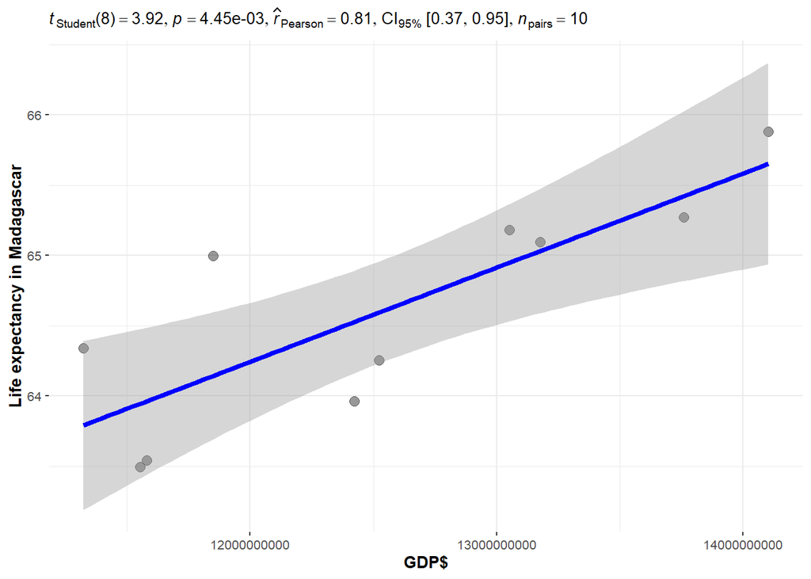

```r
library(ggstatsplot)
ggscatterstats(
  data = Madagascar,
  x = GDP_US.,
  y = Life_expectancy_at_birth,
  xlab = 'GDP$',
  ylab = 'Life expectancy in Madagascar',
  bf.message = FALSE,
  marginal = FALSE # remove histograms
)
```

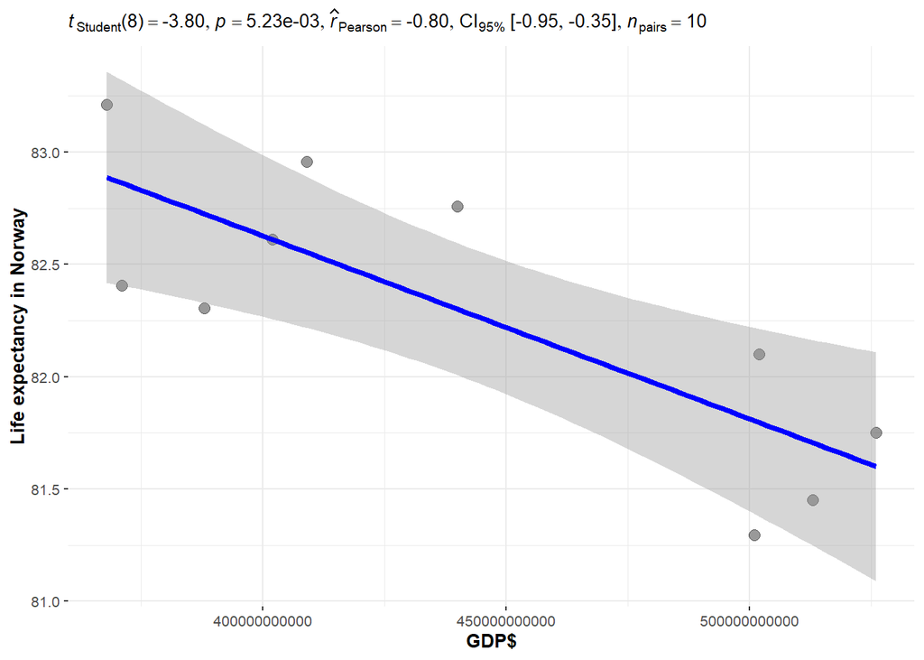

```r
ggscatterstats(
  data = Norway,
  x = GDP_US.,
  y = Life_expectancy_at_birth,
  xlab = 'GDP$',
  ylab = 'Life expectancy in Norway',
  bf.message = FALSE,
  marginal = FALSE # remove histograms
)
```

```r
colnames(data)
```

```
##  [1] "Country_Name"
##  [2] "Country_Code"
##  [3] "Time"
##  [4] "Access_to_electricity._percentage_of_pop"
##  [5] "Life_expectancy_at_birth"
##  [6] "Mortality_rate_under_5_per_1.000_live_births"
##  [7] "Political_Stability.Absence_of_Violence.Terrorism._Percentile_R"
##  [8] "Population_total"
##  [9] "Real_interest_rate_perc"
## [10] "Consumer_price_index_2010._100"
## [11] "GDP_US."
## [12] "GDP_per_Capita"
```

I’ll now carry out some correlation of all of the variables and create a correlation matrix to verify for potential associations:

considering the variable data type:

Country_Name | Categorical nominal |  
Country_Code | Categorical nominal |  
Time | Discrete |  
Access_to_electricity._percentage_of_pop | Discrete |  
Life_expectancy_at_birth | Continuous |  
Mortality_rate_under_5_per_1.000_live_births | Discrete |  
Political_Stability.Absence_of_Violence.Terrorism._Percentile_R | Discrete |  
Population_total | Continuous |  
Consumer_price_index_2010._100 | Discrete |

“Real_interest_rate_perc”|Continuous | GDP_US. | Continuous | | GDP_per_Capita | Continuous |

I’ll take off the first 3 and then build a correlation table using spearman, as i have few discrete variables as stated above: **also come back here when you have less variables

```r
reduced_data=data[c("Access_to_electricity._percentage_of_pop","Life_expectancy_at_birth"  ,"Mortality_rate_under_5_per_1.000_live_births","Political_Stability.Absence_of_Violence.Terrorism._Percentile_R","Population_total" ,"Real_interest_rate_perc", "Consumer_price_index_2010._100" , "GDP_US." , "GDP_per_Capita")]
```

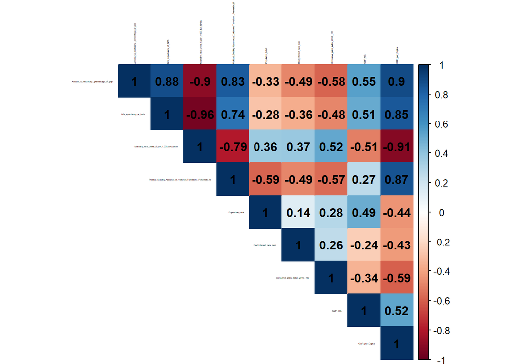

```r
cor_mat <- cor(reduced_data, method = 'spearman')
corrplot(cor_mat, method = "color", type = "upper", tl.cex = 0.2, tl.col = "black", addCoef.col = "black")
```

This other way shows correlation between all the variables

```r
library(correlation)
correlation::correlation(reduced_data,
  include_factors = TRUE, method = "auto"
) #include factors=This argument specifies that factors (categorical variables) should be included in the correlation analysis.
```

```
## # Correlation Matrix (auto-method)
##
## Parameter1                                                      |                                                      Parameter2 |        r |         95% CI | t(118) |         p
## ----------------------------------------------------------------------------------------------------------------------------------------------------------------------------------
## Access_to_electricity._percentage_of_pop                        |                                        Life_expectancy_at_birth |     0.81 | [ 0.74,  0.87] |  15.22 | < .001***
## Access_to_electricity._percentage_of_pop                        |                    Mortality_rate_under_5_per_1.000_live_births |    -0.93 | [-0.95, -0.90] | -26.67 | < .001***
## Access_to_electricity._percentage_of_pop                        | Political_Stability.Absence_of_Violence.Terrorism._Percentile_R |     0.58 | [ 0.45,  0.69] |   7.75 | < .001***
## Access_to_electricity._percentage_of_pop                        |                                                Population_total |     0.12 | [-0.06,  0.29] |   1.29 | > .999
## Access_to_electricity._percentage_of_pop                        |                                         Real_interest_rate_perc |    -0.55 | [-0.67, -0.42] |  -7.22 | < .001***
## Access_to_electricity._percentage_of_pop                        |                                  Consumer_price_index_2010._100 |    -0.46 | [-0.59, -0.30] |  -5.61 | < .001***
## Access_to_electricity._percentage_of_pop                        |                                                         GDP_US. |     0.45 | [ 0.30,  0.58] |   5.49 | < .001***
## Access_to_electricity._percentage_of_pop                        |                                                  GDP_per_Capita |     0.54 | [ 0.40,  0.66] |   7.03 | < .001***
## Life_expectancy_at_birth                                        |                    Mortality_rate_under_5_per_1.000_live_births |    -0.93 | [-0.95, -0.90] | -27.90 | < .001***
## Life_expectancy_at_birth                                        | Political_Stability.Absence_of_Violence.Terrorism._Percentile_R |     0.77 | [ 0.69,  0.84] |  13.22 | < .001***
## Life_expectancy_at_birth                                        |                                                Population_total |    -0.16 | [-0.33,  0.02] |  -1.81 | 0.513
## Life_expectancy_at_birth                                        |                                         Real_interest_rate_perc |    -0.41 | [-0.55, -0.25] |  -4.94 | < .001***
## Life_expectancy_at_birth                                        |                                  Consumer_price_index_2010._100 |    -0.51 | [-0.63, -0.36] |  -6.36 | < .001***
## Life_expectancy_at_birth                                        |                                                         GDP_US. |     0.40 | [ 0.23,  0.54] |   4.68 | < .001***
## Life_expectancy_at_birth                                        |                                                  GDP_per_Capita |     0.74 | [ 0.65,  0.81] |  12.02 | < .001***
## Mortality_rate_under_5_per_1.000_live_births                    | Political_Stability.Absence_of_Violence.Terrorism._Percentile_R |    -0.66 | [-0.75, -0.55] |  -9.64 | < .001***
## Mortality_rate_under_5_per_1.000_live_births                    |                                                Population_total | 4.72e-03 | [-0.17,  0.18] |   0.05 | > .999
## Mortality_rate_under_5_per_1.000_live_births                    |                                         Real_interest_rate_perc |     0.39 | [ 0.23,  0.53] |   4.58 | < .001***
## Mortality_rate_under_5_per_1.000_live_births                    |                                  Consumer_price_index_2010._100 |     0.53 | [ 0.39,  0.65] |   6.76 | < .001***
## Mortality_rate_under_5_per_1.000_live_births                    |                                                         GDP_US. |    -0.42 | [-0.56, -0.26] |  -5.06 | < .001***
## Mortality_rate_under_5_per_1.000_live_births                    |                                                  GDP_per_Capita |    -0.64 | [-0.73, -0.52] |  -8.95 | < .001***
## Political_Stability.Absence_of_Violence.Terrorism._Percentile_R |                                                Population_total |    -0.45 | [-0.58, -0.30] |  -5.49 | < .001***
## Political_Stability.Absence_of_Violence.Terrorism._Percentile_R |                                         Real_interest_rate_perc |    -0.55 | [-0.66, -0.41] |  -7.10 | < .001***
## Political_Stability.Absence_of_Violence.Terrorism._Percentile_R |                                  Consumer_price_index_2010._100 |    -0.43 | [-0.56, -0.27] |  -5.10 | < .001***
```

[output cut: 15 more lines]

```r
#method= auto choose automaticly which one is the best method to use, based on the type of variable
#(continuous-->Pearson,discrete--->Spearman etc.etc)
```

*Anyways review those the big correlations method once you have reduced the numbers of variables*

**part 3**

I’ll now test if the mean in GDP$ from the least of the developed country is equal or not to the mean of the most developed country in our reserch using the indipendent 2 sample t.test

I’ll state the null hypotesis to be: h0:There is no significant statistical difference between the mean of the 2 countries( Madagascar/NOrway)

And the Alternative hypotesis to be: h1:There is s significant statistical difference between the mean of the 2 countries( Madagascar/NOrway)

We have previusly assessed that the 2 variables data are normaly distributed and they are indipendent so we can dive straight to the test:

```r
t.test(Madagascar$GDP_US.,Norway$GDP_US.)
```

```
##
##  Welch Two Sample t-test
##
## data:  Madagascar$GDP_US. and Norway$GDP_US.
## t = -21.6813248978167756, df = 9.00432142377808731, p-value =
## 0.0000000044207382513432574
## alternative hypothesis: true difference in means is not equal to 0
## 95 percent confidence interval:
##  -474271618802.70043945 -384660102225.69952393
## sample estimates:
##              mean of x              mean of y
##  12534139485.799999237 442000000000.000000000
```

At 95% confidence level the p-value is way below the threshold of 0.05 So we reject the null hypotesis of no significant statistical difference between the means of the 2 countries

Visualize it:

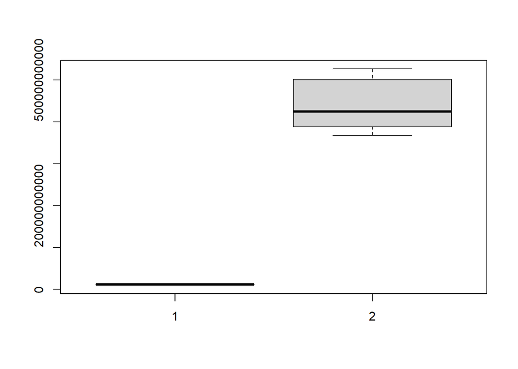

```r
boxplot(Madagascar$GDP_US.,Norway$GDP_US.)
```

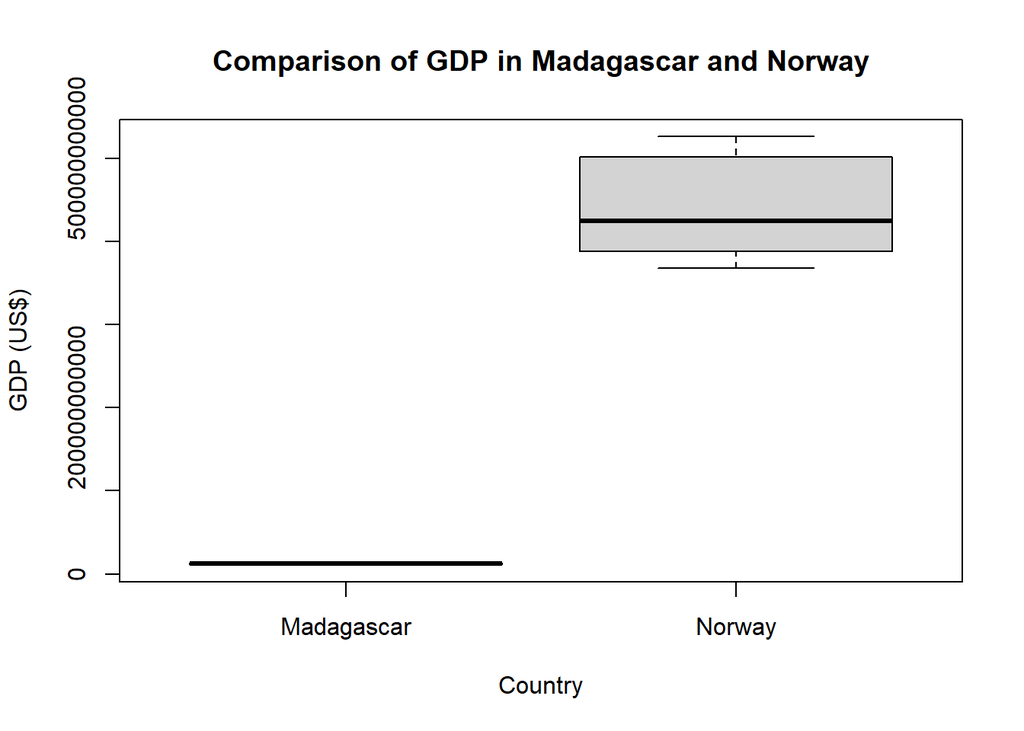

```r
boxplot(GDP_US. ~ Country_Name, data = rbind(Madagascar, Norway),
        main = "Comparison of GDP in Madagascar and Norway",
        xlab = "Country", ylab = "GDP (US$)")
```

I’ll now focus in testing if there is a significant difference in GPD$ mean betwwen the groups of nation in developing countries carring out a one way anova: ANOVA is used when we want to experiment effect of two or more levels of one or two (or even three) independent variables on a dependent variable. I can generate some hypotesis tes as: h0 : all of the country means GPD$ are the same h1: at least one of the country GPD$ differ from the others

**ANOVA Assumptions**

Like the t-test, ANOVA is also a parametric test and has some assumptions. To perform ANOVA, the data needs to “pass” six assumptions to give us a valid result. However, even when our data fails certain assumptions, there is often a solution to overcome this failure.

Assumption 1: Dependent variable should be continuous. *pass* Assumption 2: Independent variables should be categorical with two or more categories.*pass* Assumption 3: Observations should be independent, which means that there is no relationship between the observations in each group or between the groups themselves.*pass* Assumption 4: There should be no significant outliers.*pass* Assumption 5: Dependent variable should be approximately normally distributed for each category of the independent variable.*pass* Assumption 6: Variances of the dependent variable within each category should be homogeneous.

we check for the outliers:

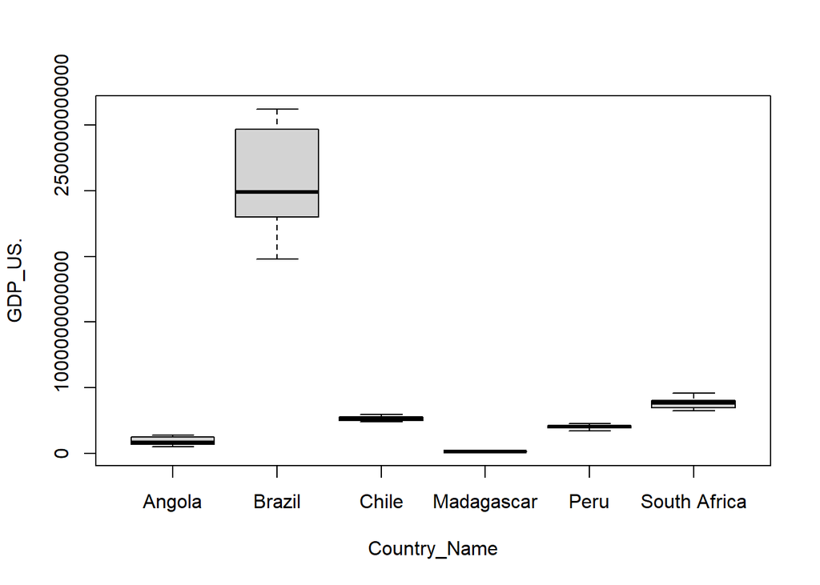

```r
boxplot(GDP_US.~Country_Name,data=developing_countries)
```

*check for the distribution*

```r
developing_countries$Country_Name=as.factor(developing_countries$Country_Name)#transform the country_name variable as factor
byf.shapiro(GDP_US.~Country_Name,data = developing_countries)
```

```
##
##  Shapiro-Wilk normality tests
##
## data:  GDP_US. by Country_Name
##
##                   W p-value
## Angola       0.9056  0.2522
## Brazil       0.9069  0.2602
## Chile        0.9518  0.6901
## Madagascar   0.9358  0.5077
## Peru         0.9585  0.7681
## South Africa 0.9668  0.8597
```

So GPDUS$ for each country is normaly distributed

We check for Variances of the dependent variable within each category should be homogeneous.

```r
bartlett.test(GDP_US.~Country_Name,data = developing_countries)
```

```
##
##  Bartlett test of homogeneity of variances
##
## data:  GDP_US. by Country_Name
## Bartlett's K-squared = 200.716771460909683, df = 5, p-value <
## 0.000000000000000222044604925031
```

This means that there is evidence to suggest that the GDP_US$ level variances are significantly different for the Countries levels.I’ll specify this on the anova formula.

also check if data is balanced: **first transform developing country as factor:

```r
developing_countries$Country_Name=as.factor(developing_countries$Country_Name)
summary(developing_countries$Country_Name)
```

```
##       Angola       Brazil        Chile   Madagascar         Peru South Africa
##           10           10           10           10           10           10
```

H0:there is no significt statistic difference between the GPD_US$ between the countries included in developing countries group. H1: there is a signifivcant difference.

```r
oneway.test(GDP_US.~Country_Name,data = developing_countries,var.equal = FALSE)
```

```
##
##  One-way analysis of means (not assuming equal variances)
##
## data:  GDP_US. and Country_Name
## F = 843.229587536768122, num df = 5.0000000000000000, denom df =
## 21.0692289628134901, p-value < 0.000000000000000222044604925031
```

```r
#or

res_aov=aov(GDP_US.~Country_Name,data = developing_countries)#This already takes into account unequal variances when comparing groups, so you don't need to set var.equal explicitly
report(res_aov)
```

```
## The ANOVA (formula: GDP_US. ~ Country_Name) suggests that:
##
##   - The main effect of Country_Name is statistically significant and large (F(5,
## 54) = 247.52, p < .001; Eta2 = 0.96, 95% CI [0.94, 1.00])
##
## Effect sizes were labelled following Field's (2013) recommendations.
```

The Test gives as a result that there is a significant difference in GPD$ means between the countries at least for one country in developing countries so we reject the null hypotesis.

We can reserch further to find out which specific countries exhibit differences in their mean GDP compared to others within this group.

To go around this problem and still go further with our researc we can use : **Post-hoc test**

Tukey HSD, used to compare all groups to each other (so all possible comparisons of 2 groups)

```r
post_test=TukeyHSD(res_aov)
post_test
```

```
##   Tukey multiple comparisons of means
##     95% family-wise confidence level
##
## Fit: aov(formula = GDP_US. ~ Country_Name, data = developing_countries)
##
## $Country_Name
##                                            diff                      lwr
## Brazil-Angola            2004262401617.89868164  1794933478508.522705078
## Chile-Angola              174062401617.89978027   -35266521491.476257324
## Madagascar-Angola         -78203458896.30027771  -287532382005.676330566
## Peru-Angola               110562401617.89979553   -98766521491.476242065
## South Africa-Angola       294962401617.89978027    85633478508.523742676
## Chile-Brazil            -1830199999999.99902344 -2039528923109.375000000
## Madagascar-Brazil       -2082465860514.19897461 -2291794783623.575195312
## Peru-Brazil             -1893699999999.99902344 -2103028923109.375000000
## South Africa-Brazil     -1709299999999.99902344 -1918628923109.375000000
## Madagascar-Chile         -252265860514.20007324  -461594783623.576110840
## Peru-Chile                -63500000000.00000000  -272828923109.376037598
## South Africa-Chile        120900000000.00000000   -88428923109.376037598
## Peru-Madagascar           188765860514.20007324   -20563062595.175964355
## South Africa-Madagascar   373165860514.20007324   163836937404.824035645
## South Africa-Peru         184400000000.00000000   -24928923109.376037598
##                                              upr
## Brazil-Angola            2213591324727.274902344
## Chile-Angola              383391324727.275817871
## Madagascar-Angola         131125464213.075759888
## Peru-Angola               319891324727.275817871
## South Africa-Angola       504291324727.275817871
## Chile-Brazil            -1620871076890.623046875
## Madagascar-Brazil       -1873136937404.822998047
## Peru-Brazil             -1684371076890.623046875
## South Africa-Brazil     -1499971076890.623046875
## Madagascar-Chile          -42936937404.824035645
## Peru-Chile                145828923109.376037598
## South Africa-Chile        330228923109.376037598
## Peru-Madagascar           398094783623.576110840
## South Africa-Madagascar   582494783623.576171875
## South Africa-Peru         393728923109.376037598
##                                                      p adj
## Brazil-Angola           0.00000000000043731684999999999768
## Chile-Angola            0.15561995236728687341809518329683
## Madagascar-Angola       0.87770051142199889682160574011505
## Peru-Angola             0.62744006795354101413408898224588
## South Africa-Angola     0.00151710097143165079103255266091
## Chile-Brazil            0.00000000000043731684999999999768
## Madagascar-Brazil       0.00000000000043731684999999999768
## Peru-Brazil             0.00000000000043731684999999999768
## South Africa-Brazil     0.00000000000043731684999999999768
## Madagascar-Chile        0.00965730232947026312473326470354
## Peru-Chile              0.94577458538873915294686867127893
## South Africa-Chile      0.53369541979622114880044136953074
## Peru-Madagascar         0.09958628372663136385511961634620
## South Africa-Madagascar 0.00003534412713068757483370063710
## South Africa-Peru       0.11418372918236652235890460360679
```

From result we see that there is a big significant statisical differnce in GPD$ mean from *Brazil* with any other country in the group. also significant difference in mean is given by the pairs: *South Africa -Angola* *South Africa-Madagascar* *Madagascar-Chile*

**reject the null hypotesis** **So brazil has the best economic performance among the developing countries taken in consideration with much higher GPD compared to any other country of the same group.**

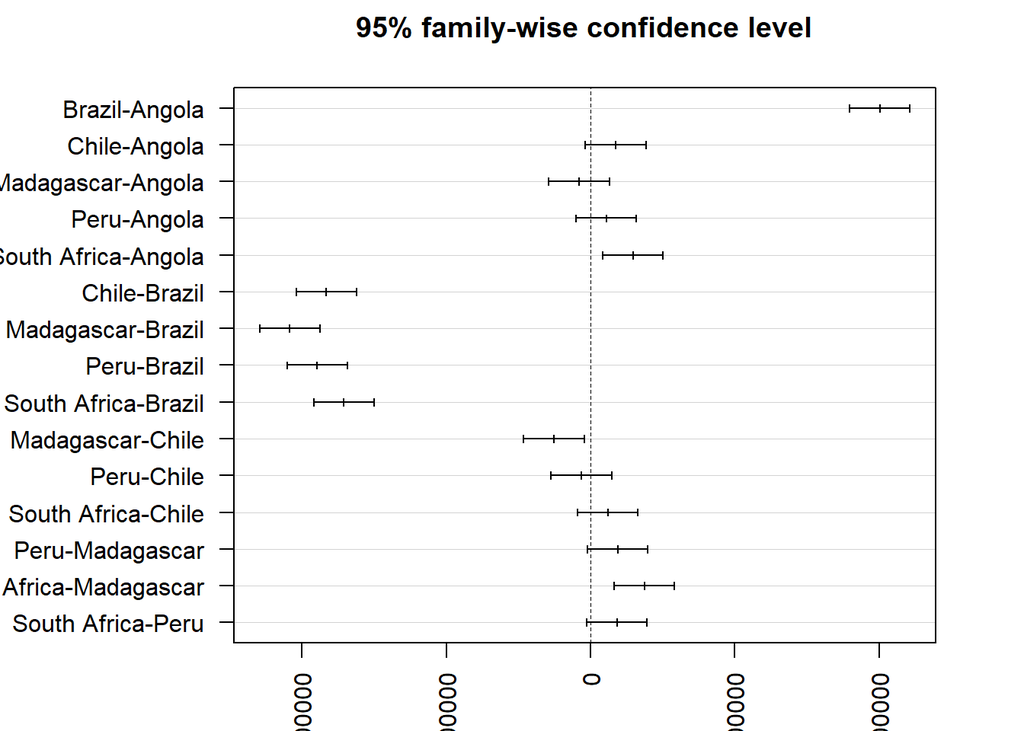

```r
# Plot the results with rotated labels
par(mar = c(3, 8, 3, 3))  # Adjust the margins for better label display
plot(post_test, las = 2)
```

I will now perform another **1 way anova:**

Does political stability have a significant impact on Gross Domestic Product (GDP) across developing countries (country taken in consideration),

I’ll first need to work with political stability feature and generate a categorical variable from it. the variable has a rank from 0 to 100,I’ll associate any observation <=50 with low political stability and >50 hight political stability:

```r
developing_countries$Political_Stability_Cat = cut(developing_countries$Political_Stability.Absence_of_Violence.Terrorism._Percentile_R, breaks = c(0, 50, 100), labels = c("Low", "High"))

str(developing_countries$Political_Stability_Cat)
```

```
##  Factor w/ 2 levels "Low","High": 1 1 1 1 1 1 1 1 1 1 ...
```

```r
summary(developing_countries$Political_Stability_Cat)
```

```
##  Low High
##   52    8
```

```r
summary(developed_countries$Country_Name)
```

```
##    Length     Class      Mode
##        60 character character
```

So we have an inbalaced data here

let’s check for the assumption: Assumption 1: Dependent variable should be continuous. Assumption 2: Independent variables should be categorical with two or more categories. Assumption 3: Observations should be independent, which means that there is no relationship between the observations in each group or between the groups themselves. Assumption 4: There should be no significant outliers. Assumption 5: Dependent variable should be approximately normally distributed for each category of the independent variable. Assumption 6: Variances of the dependent variable within each category should be homogeneous.

*check outliers in the new categorical var:*

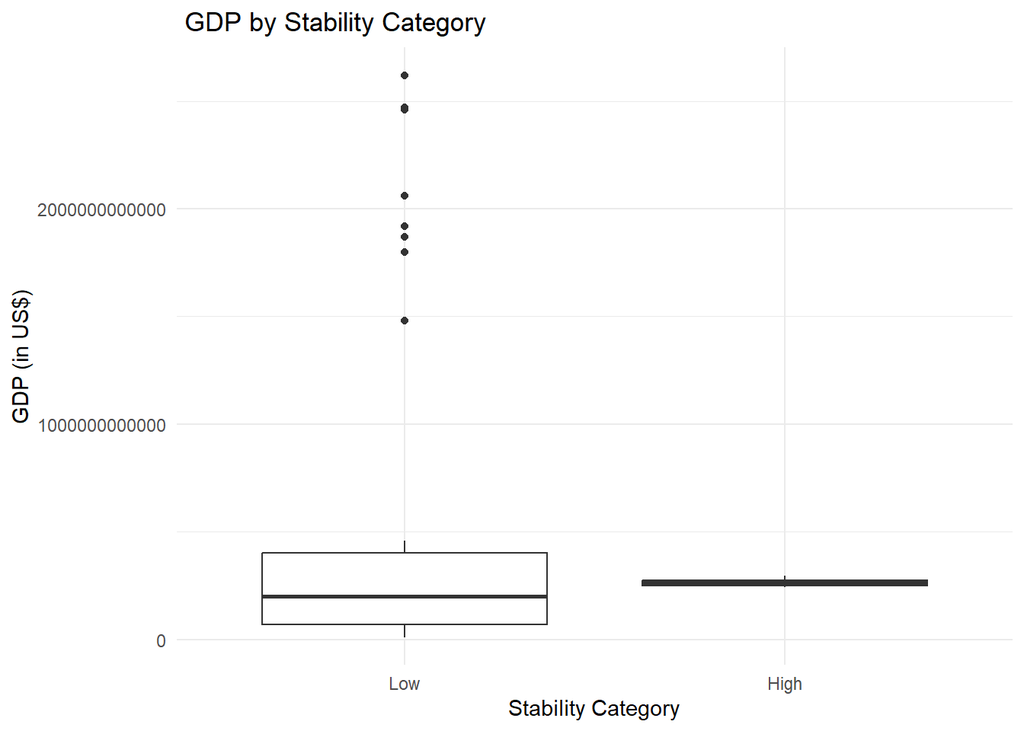

```r
ggplot(developing_countries, aes(x = Political_Stability_Cat, y = GDP_US.)) +
  geom_boxplot() +
  xlab("Stability Category") +
  ylab("GDP (in US$)") +
  ggtitle(" GDP by Stability Category") +
  theme_minimal()
```

There is some outliers but it does not effect the data significantly

*I already checked for normality in the group of country category. will now check for normal distribution of the data in the political stability variable:

```r
byf.shapiro(GDP_US.~Political_Stability_Cat,data=developing_countries)
```

```
##
##  Shapiro-Wilk normality tests
##
## data:  GDP_US. by Political_Stability_Cat
##
##           W         p-value
## Low  0.6555 0.0000000008756 ***
## High 0.9585          0.7961
## ---
## Signif. codes:
##   0 '***' 0.0010000000000000000208 '**' 0.010000000000000000208 '*'
##   0.050000000000000002776 '.' 0.10000000000000000555 ' ' 1
```

so data is not normaly distributed in this variable( political stability) as it is discrete

the data is not normaly distribute ,thus i ’ll use a non parametric method to analyze the data

*non parametric 1 way anova:*

```r
kruskal.test(GDP_US.~Political_Stability_Cat,data = developing_countries)
```

```
##
##  Kruskal-Wallis rank sum test
##
## data:  GDP_US. by Political_Stability_Cat
## Kruskal-Wallis chi-squared = 0.682925838680843889, df = 1, p-value =
## 0.40858103920056349
```

h0:no difference in means h1: difference in means we cannot reject the null hypotesis thus political stability does not impact the GPD_US$ mean between country in the developing country group

**Part 4** *Regression analysis*

Predict the GPD per capita of 2 developed countries(Italy and new zeland using life expectancy and mortality rate) and the political stability rank of 2 developing (Brazil and south africa using consumer price index as indipendent variable) , and which specific factors are the most significant predictors of GDP?“(regression)

create a correlation matrix:

```r
reduced_developing=developing_countries[c("Access_to_electricity._percentage_of_pop","Life_expectancy_at_birth"  ,"Mortality_rate_under_5_per_1.000_live_births","Political_Stability.Absence_of_Violence.Terrorism._Percentile_R","Population_total" ,"Real_interest_rate_perc", "Consumer_price_index_2010._100" , "GDP_US." , "GDP_per_Capita")]
```

```r
group1 = developed_countries %>%
  filter(Country_Name%in% c('Italy', 'New Zealand')) %>%
  group_by(Country_Name,Time)
group1=as.data.frame(group1)
group1
```

```
##    Country_Name Country_Code Time Access_to_electricity._percentage_of_pop
## 1         Italy          ITA 2011                                      100
## 2         Italy          ITA 2012                                      100
## 3         Italy          ITA 2013                                      100
## 4         Italy          ITA 2014                                      100
## 5         Italy          ITA 2015                                      100
## 6         Italy          ITA 2016                                      100
## 7         Italy          ITA 2017                                      100
## 8         Italy          ITA 2018                                      100
## 9         Italy          ITA 2019                                      100
## 10        Italy          ITA 2020                                      100
## 11  New Zealand          NZL 2011                                      100
## 12  New Zealand          NZL 2012                                      100
## 13  New Zealand          NZL 2013                                      100
## 14  New Zealand          NZL 2014                                      100
```

[output cut: 90 more lines]

create a reduced group 1 including only the numerical variables

```r
reduced_group1=group1[c("Access_to_electricity._percentage_of_pop","Life_expectancy_at_birth"  ,"Mortality_rate_under_5_per_1.000_live_births","Political_Stability.Absence_of_Violence.Terrorism._Percentile_R","Population_total" ,"Real_interest_rate_perc", "Consumer_price_index_2010._100" , "GDP_US." , "GDP_per_Capita")]
```

*look at the correlation plot you generated before*

```r
cor_mat <- cor(reduced_group1, method = 'spearman')
```

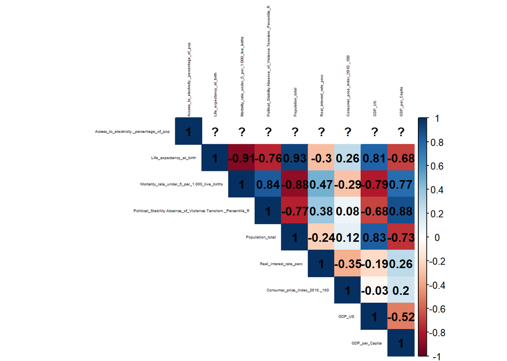

```r
corrplot(cor_mat, method = "color", type = "upper", tl.cex = 0.3, tl.col = "black", addCoef.col = "black")
```

```r
cor(group1$Mortality_rate_under_5_per_1.000_live_births,group1$GDP_per_Capita)
```

```
## [1] 0.81703044393330692685
```

```r
shapiro.test(group1$Mortality_rate_under_5_per_1.000_live_births)
```

```
##
##  Shapiro-Wilk normality test
##
## data:  group1$Mortality_rate_under_5_per_1.000_live_births
## W = 0.910914088365276653, p-value = 0.066344830345225217
```

```r
cor(group1$Life_expectancy_at_birth,group1$GDP_per_Capita)
```

```
## [1] -0.71269534305553505771
```

```r
shapiro.test(group1$Life_expectancy_at_birth)
```

```
##
##  Shapiro-Wilk normality test
##
## data:  group1$Life_expectancy_at_birth
## W = 0.943797142164790825, p-value = 0.28256018653155851
```

check the assumption:

```r
model2=lm(group1$GDP_per_Capita~group1$Life_expectancy_at_birth+(group1$Mortality_rate_under_5_per_1.000_live_births))
summary.lm(model2)
```

```
##
## Call:
## lm(formula = group1$GDP_per_Capita ~ group1$Life_expectancy_at_birth +
##     (group1$Mortality_rate_under_5_per_1.000_live_births))
##
## Residuals:
##                  Min                   1Q               Median
## -4958.41706250228799 -1851.41224940434495   355.41793250375332
##                   3Q                  Max
##  2575.03165153205828  3699.91737063876963
##
## Coefficients:
##                                                                  Estimate
## (Intercept)                                          -7232.39009635744605
## group1$Life_expectancy_at_birth                        354.88277799078537
## group1$Mortality_rate_under_5_per_1.000_live_births   3559.19240804711899
##                                                                Std. Error
## (Intercept)                                         162920.28154235269176
## group1$Life_expectancy_at_birth                       1921.79631640665707
## group1$Mortality_rate_under_5_per_1.000_live_births   1242.04336640702127
##                                                                   t value
## (Intercept)                                         -0.044389999999999999
## group1$Life_expectancy_at_birth                      0.184659999999999991
## group1$Mortality_rate_under_5_per_1.000_live_births  2.865590000000000082
##                                                     Pr(>|t|)
## (Intercept)                                         0.965109
## group1$Life_expectancy_at_birth                     0.855679
## group1$Mortality_rate_under_5_per_1.000_live_births 0.010715 *
## ---
## Signif. codes:
##   0 '***' 0.0010000000000000000208 '**' 0.010000000000000000208 '*'
##   0.050000000000000002776 '.' 0.10000000000000000555 ' ' 1
##
## Residual standard error: 2766.0533348350604683 on 17 degrees of freedom
## Multiple R-squared:  0.66820429063057374,    Adjusted R-squared:  0.62916950129299409
## F-statistic: 17.118173351771631 on 2 and 17 DF,  p-value: 0.000084606067181823373
```

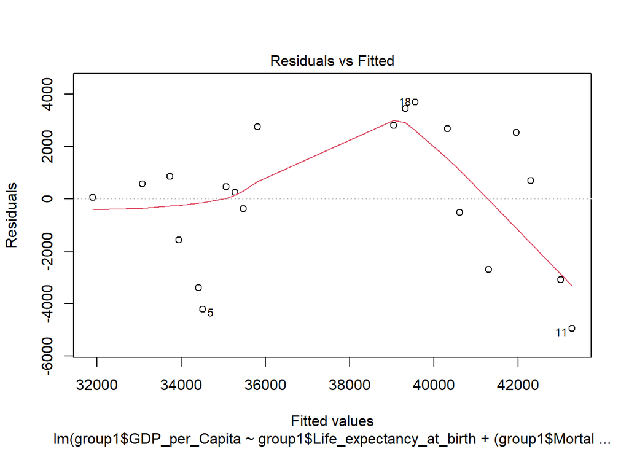

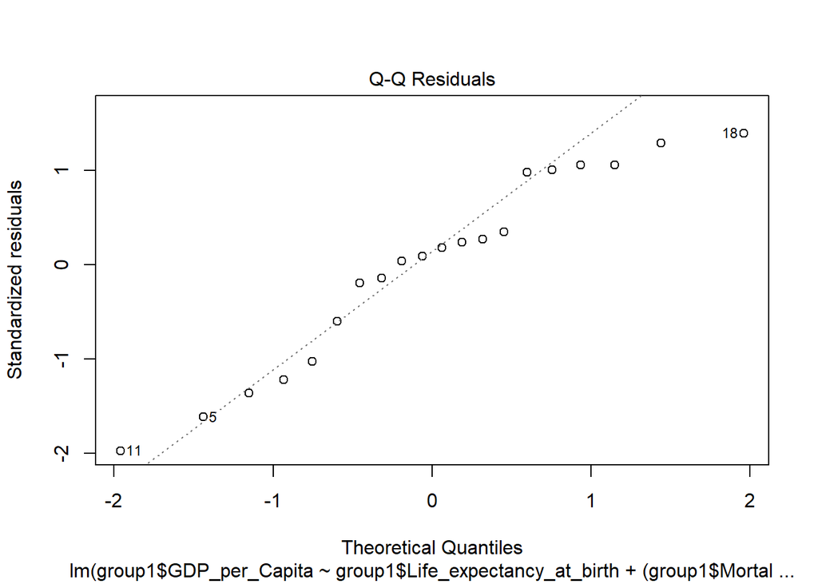

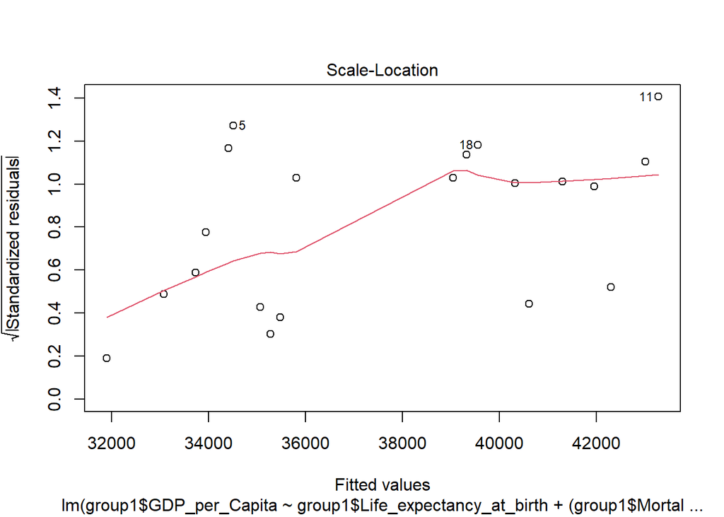

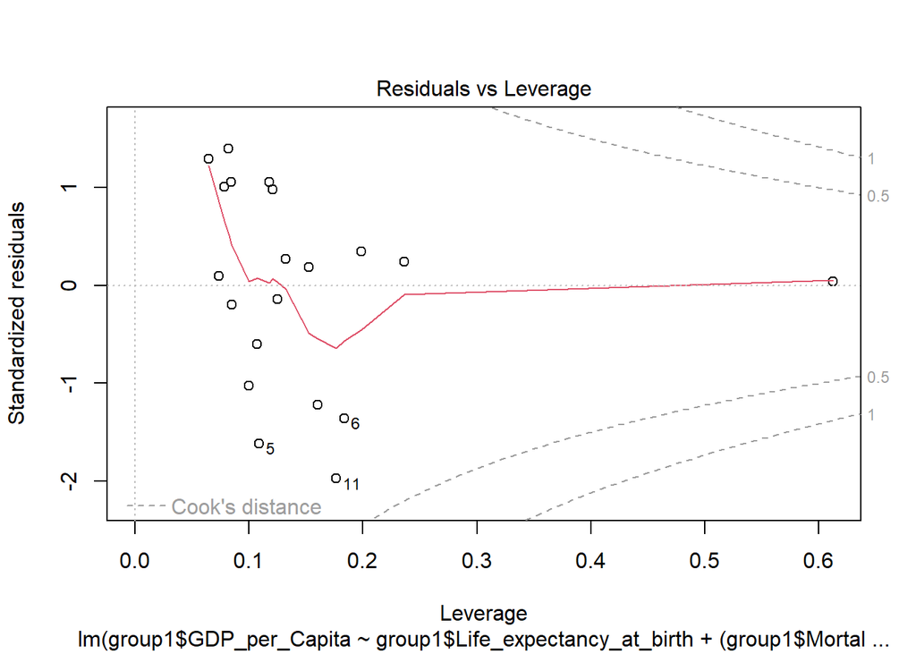

```r
plot(model2)
```

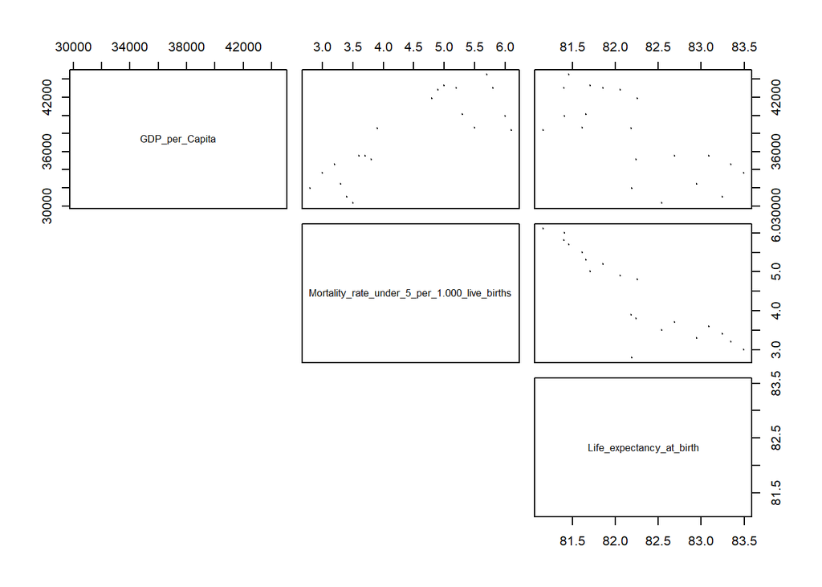

```r
pairs(reduced_group1[, c("GDP_per_Capita", "Mortality_rate_under_5_per_1.000_live_births", "Life_expectancy_at_birth")], lower.panel = NULL, pch = 19, cex = 0.2)
```

**multilinearity:**

```r
vif(model2)
```

```
##                     group1$Life_expectancy_at_birth
##                               4.6853476663027944227
## group1$Mortality_rate_under_5_per_1.000_live_births
##                               4.6853476663027944227
```

```r
group2 = developing_countries %>%
  filter(Country_Name%in% c('Brazil', 'South Africa')) %>%
  group_by(Country_Name,Time)
group2=as.data.frame(group2)
group2
```

```
##    Country_Name Country_Code Time Access_to_electricity._percentage_of_pop
## 1  South Africa          ZAF 2011                    83.599999999999994316
## 2  South Africa          ZAF 2012                    85.200000000000002842
## 3  South Africa          ZAF 2013                    85.200000000000002842
## 4  South Africa          ZAF 2014                    85.900000000000005684
## 5  South Africa          ZAF 2015                    85.299999999999997158
## 6  South Africa          ZAF 2016                    83.900000000000005684
## 7  South Africa          ZAF 2017                    84.400000000000005684
## 8  South Africa          ZAF 2018                    84.700000000000002842
## 9  South Africa          ZAF 2019                    85.000000000000000000
## 10 South Africa          ZAF 2020                    90.000000000000000000
## 11       Brazil          BRA 2011                    99.328691000000006284
## 12       Brazil          BRA 2012                    99.519493999999994571
## 13       Brazil          BRA 2013                    99.575151000000005297
## 14       Brazil          BRA 2014                    99.650246999999993136
```

[output cut: 90 more lines]

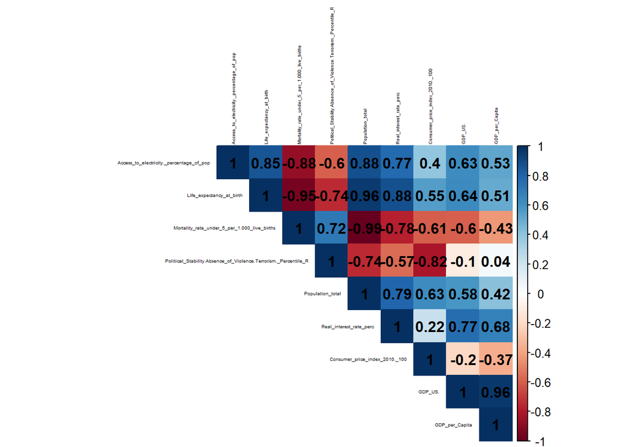

```r
reduced_group2=group2[c("Access_to_electricity._percentage_of_pop","Life_expectancy_at_birth"  ,"Mortality_rate_under_5_per_1.000_live_births","Political_Stability.Absence_of_Violence.Terrorism._Percentile_R","Population_total" ,"Real_interest_rate_perc", "Consumer_price_index_2010._100" , "GDP_US." , "GDP_per_Capita")]


cor_mat <- cor(reduced_group2, method = 'spearman')
corrplot(cor_mat, method = "color", type = "upper", tl.cex = 0.3, tl.col = "black", addCoef.col = "black")
```

here you try the correlations and the distributions

```r
shapiro.test(group2$Political_Stability.Absence_of_Violence.Terrorism._Percentile_R)
```

```
##
##  Shapiro-Wilk normality test
##
## data:  group2$Political_Stability.Absence_of_Violence.Terrorism._Percentile_R
## W = 0.974149814404980718, p-value = 0.83890065443437956
```

```r
cor(group2$Consumer_price_index_2010._100,group2$Political_Stability.Absence_of_Violence.Terrorism._Percentile_R)
```

```
## [1] -0.79850174435522258687
```

```r
shapiro.test(sqrt(group2$Consumer_price_index_2010._100))
```

```
##
##  Shapiro-Wilk normality test
##
## data:  sqrt(group2$Consumer_price_index_2010._100)
## W = 0.940602651218475305, p-value = 0.24614725556250805
```

```r
cor(sqrt(group2$GDP_per_Capita),group2$Political_Stability.Absence_of_Violence.Terrorism._Percentile_R)
```

```
## [1] 0.10155950163004141829
```

```r
shapiro.test(group2$Mortality_rate_under_5_per_1.000_live_births)
```

```
##
##  Shapiro-Wilk normality test
##
## data:  group2$Mortality_rate_under_5_per_1.000_live_births
## W = 0.804790638182903084, p-value = 0.0010193184791963507
```

so next the second model:

```r
model3=lm(group2$Political_Stability.Absence_of_Violence.Terrorism._Percentile_R~group2$Consumer_price_index_2010._100)
summary.lm(model3)
```

```
##
## Call:
## lm(formula = group2$Political_Stability.Absence_of_Violence.Terrorism._Percentile_R ~
##     group2$Consumer_price_index_2010._100)
##
## Residuals:
##                  Min                   1Q               Median
## -9.42384130027572908 -2.59001827997348144 -0.49270020547750559
##                   3Q                  Max
##  2.73670323737601384  8.14464497241573149
##
## Coefficients:
##                                                    Estimate
## (Intercept)                           71.413212306041842226
## group2$Consumer_price_index_2010._100 -0.246327247324833964
##                                                  Std. Error             t value
## (Intercept)                            6.112625068693414043 11.6829000000000001
## group2$Consumer_price_index_2010._100  0.043771497922633601 -5.6275700000000004
##                                              Pr(>|t|)
## (Intercept)                           0.0000000007757 ***
## group2$Consumer_price_index_2010._100 0.0000243781087 ***
## ---
## Signif. codes:
##   0 '***' 0.0010000000000000000208 '**' 0.010000000000000000208 '*'
##   0.050000000000000002776 '.' 0.10000000000000000555 ' ' 1
##
## Residual standard error: 4.1690477949186321993 on 18 degrees of freedom
## Multiple R-squared:  0.63760503573833316,    Adjusted R-squared:  0.61747198216824062
## F-statistic: 31.669564356868705 on 1 and 18 DF,  p-value: 0.000024378108694153656
```

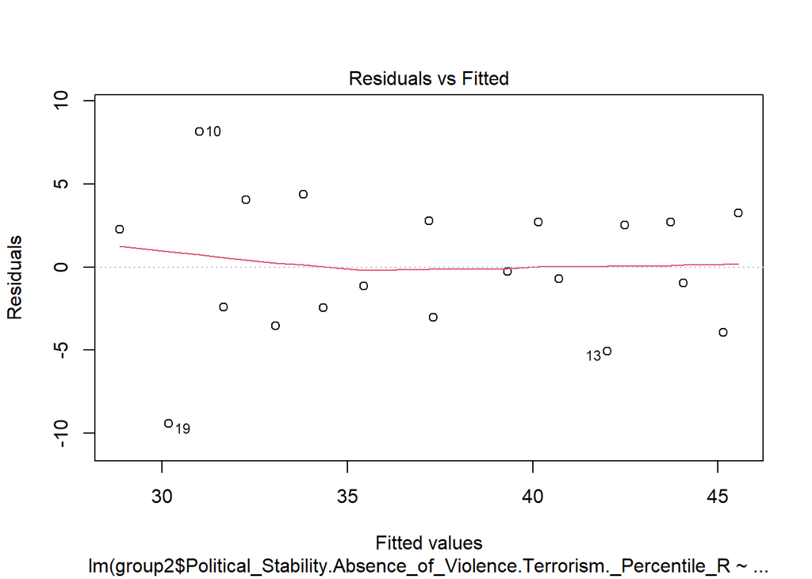

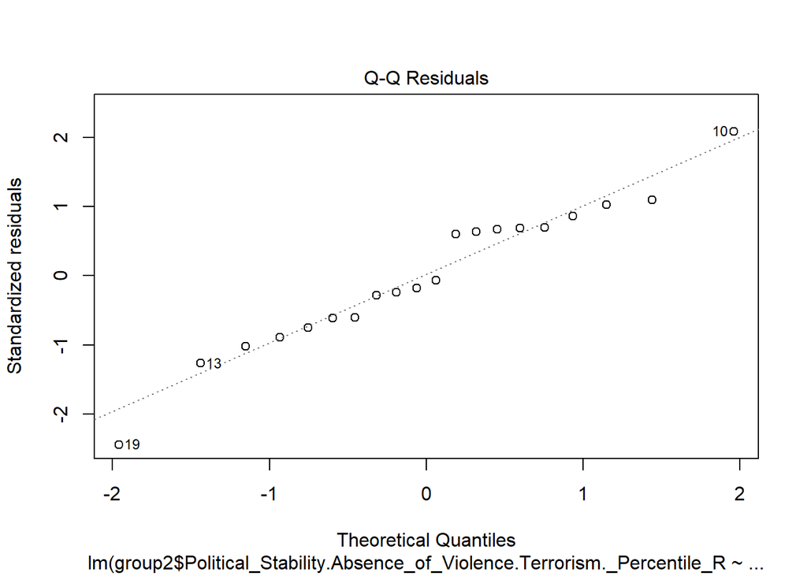

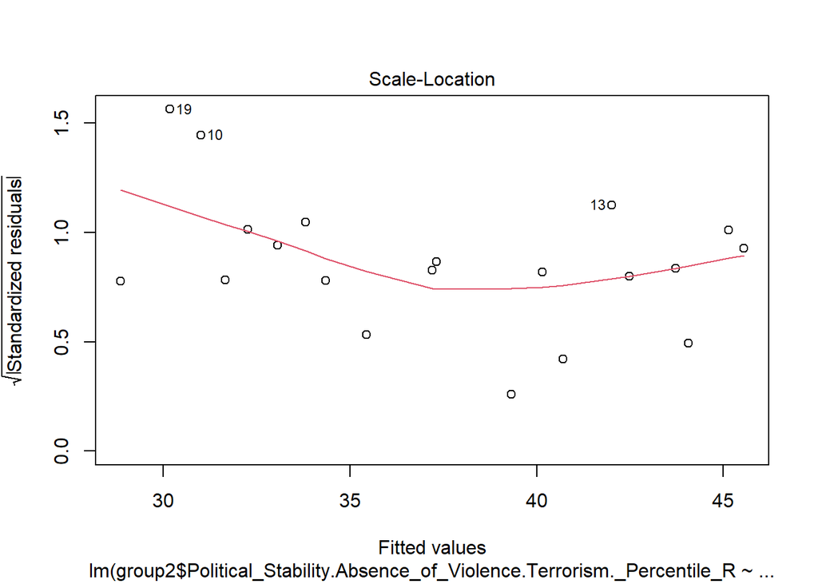

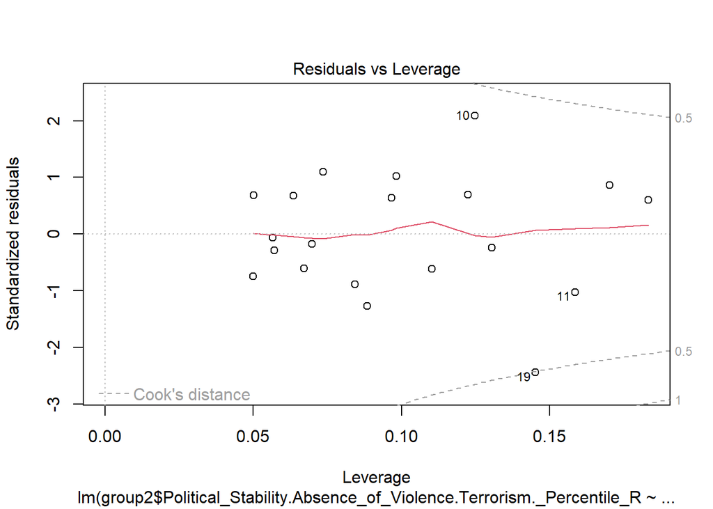

```r
plot(model3)
```

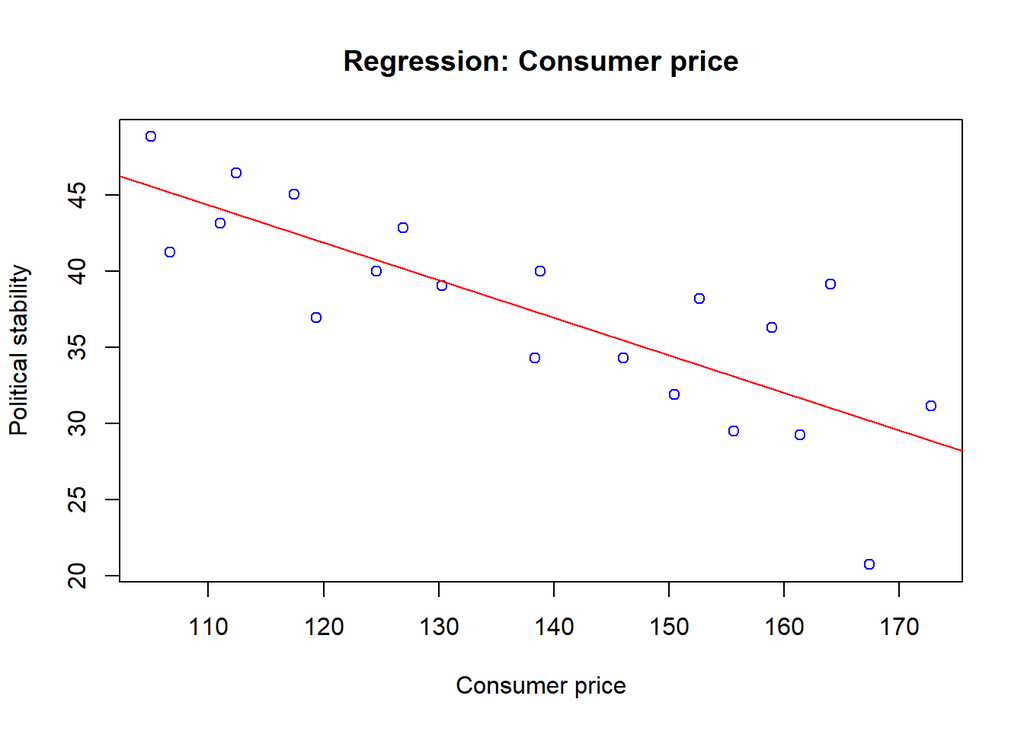

```r
plot( group2$Political_Stability.Absence_of_Violence.Terrorism._Percentile_R ~ group2$Consumer_price_index_2010._100,
     col='blue',
     main='Regression: Consumer price',
     xlab = 'Consumer price',
     ylab = 'Political stability'
     )
abline(model3,col='red')
```

**Time series**

this time series if for brazil but try to change the country as you have alredy used brazil

```r
brazil_data <- group1[group2$Country_Name == 'Brazil', ( "Political_Stability.Absence_of_Violence.Terrorism._Percentile_R")]
brazil_data <- as.data.frame(brazil_data)
brazil_data
```

```
##              brazil_data
## 1  97.630332949999996117
## 2  96.682464600000002974
## 3  98.578201289999995538
## 4  99.523811339999994630
## 5  99.047622680000003470
## 6  99.523811339999994630
## 7  98.571426389999999174
## 8  99.056602479999995126
## 9  97.169815060000004792
## 10 98.113204960000004462
```

```r
brazil_series=ts(brazil_data,start = 2011,frequency = 1)
brazil_series
```

```
## Time Series:
## Start = 2011
## End = 2020
## Frequency = 1
##                 brazil_data
##  [1,] 97.630332949999996117
##  [2,] 96.682464600000002974
##  [3,] 98.578201289999995538
##  [4,] 99.523811339999994630
##  [5,] 99.047622680000003470
##  [6,] 99.523811339999994630
##  [7,] 98.571426389999999174
##  [8,] 99.056602479999995126
##  [9,] 97.169815060000004792
## [10,] 98.113204960000004462
```

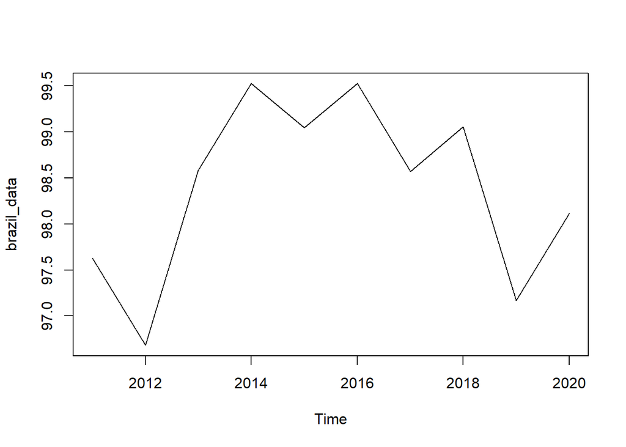

```r
plot(brazil_series)
```

There is not seasonality and a additive model could be appropiate to describe this time series we can smooth the data to find out the trend of political stability over this decade:

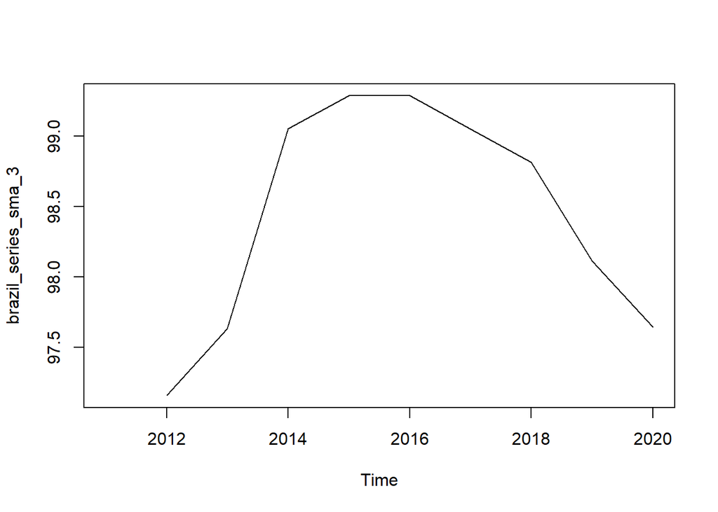

```r
brazil_series_sma_3=SMA(brazil_series,n = 2)
plot.ts(brazil_series_sma_3)
```

Forecasting using data which has no seasonality but has trend using holt winter exponential smoothing:

```r
brazil_series_forecast=HoltWinters(brazil_series,gamma = FALSE)
brazil_series_forecast
```

```
## Holt-Winters exponential smoothing with trend and without seasonal component.
##
## Call:
## HoltWinters(x = brazil_series, gamma = FALSE)
##
## Smoothing parameters:
##  alpha: 0.91339826041679372803
##  beta : 0.21587333043744691419
##  gamma: FALSE
##
## Coefficients:
##                      [,1]
## a 98.00847761485158571304
## b -0.18025218636967801911
```

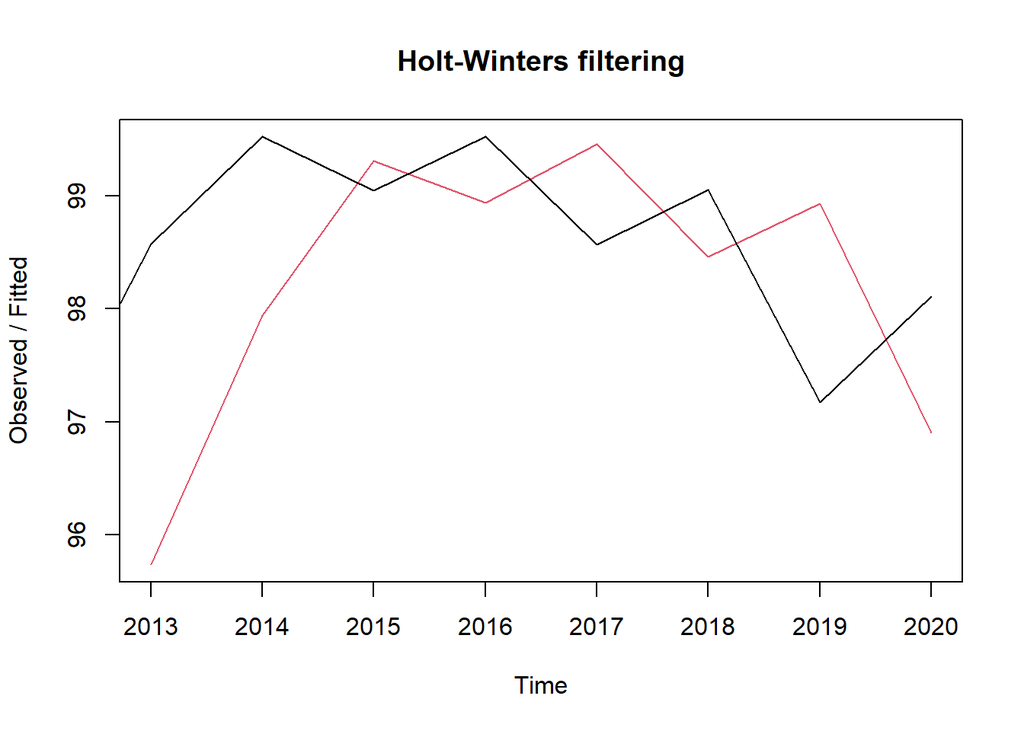

```r
plot(brazil_series_forecast)
```

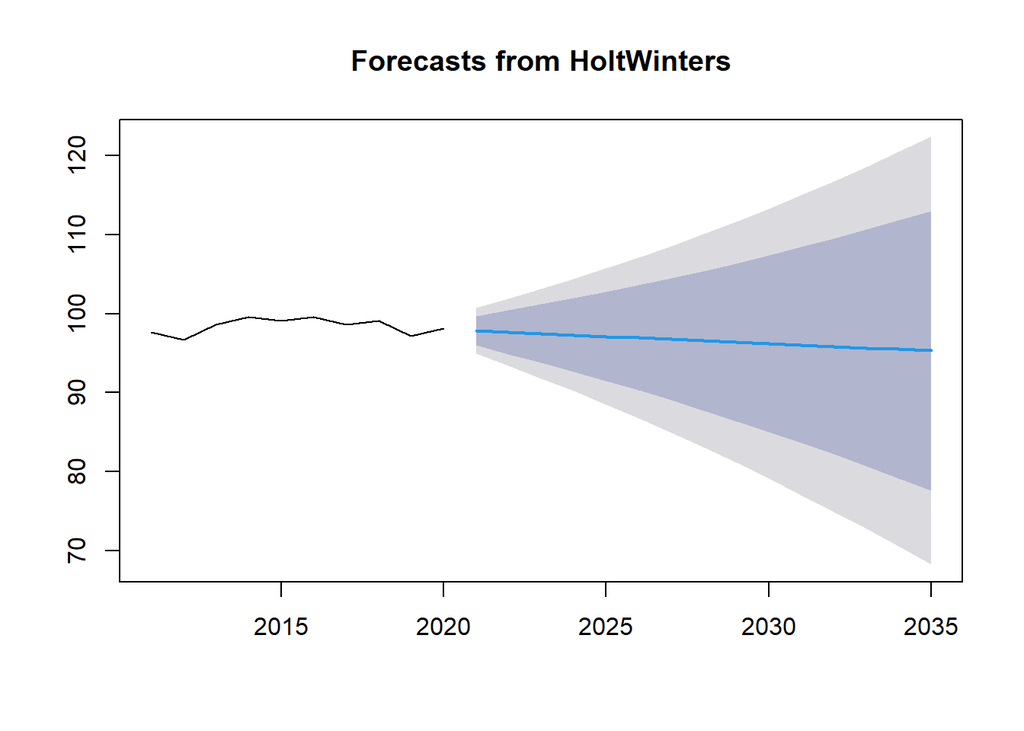

```r
brazil_series_forecast2=forecast(brazil_series_forecast,h=15)
plot(brazil_series_forecast2)
```

Try now with Singapore

```r
singapore_data <- developed_countries[developed_countries$Country_Name == 'Singapore', ( "Political_Stability.Absence_of_Violence.Terrorism._Percentile_R")]
singapore_data <- as.data.frame(singapore_data)
singapore_data
```

```
##           singapore_data
## 1  90.995262150000002066
## 2  97.156394960000000083
## 3  96.682464600000002974
## 4  93.333335880000007023
## 5  95.238098140000005287
## 6  99.047622680000003470
## 7  99.047622680000003470
## 8  98.584907529999995290
## 9  97.641510010000004627
## 10 97.169815060000004792
```

```r
singapore_time_series=ts(singapore_data,start = 2011,frequency = 1)
singapore_time_series
```

```
## Time Series:
## Start = 2011
## End = 2020
## Frequency = 1
##              singapore_data
##  [1,] 90.995262150000002066
##  [2,] 97.156394960000000083
##  [3,] 96.682464600000002974
##  [4,] 93.333335880000007023
##  [5,] 95.238098140000005287
##  [6,] 99.047622680000003470
##  [7,] 99.047622680000003470
##  [8,] 98.584907529999995290
##  [9,] 97.641510010000004627
## [10,] 97.169815060000004792
```

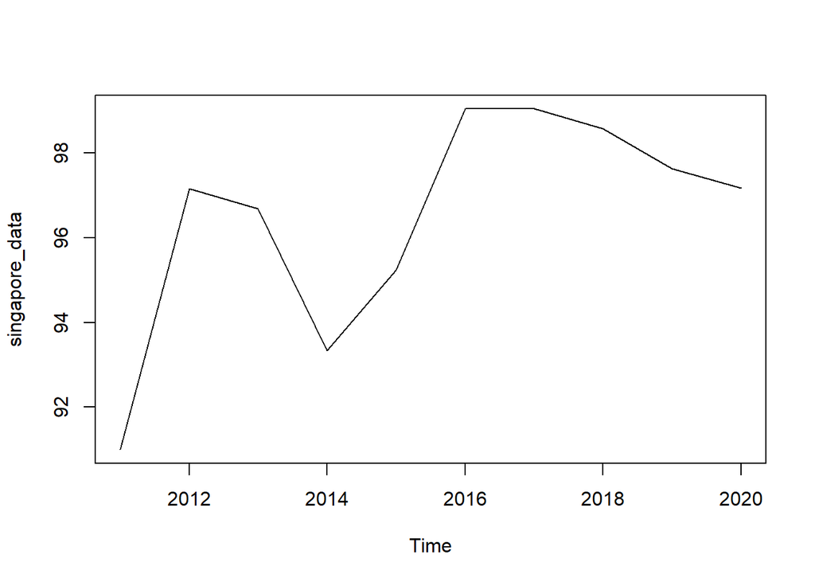

```r
plot(singapore_time_series)
```

There is not seasonality and a additive model could be appropiate to describe this time series we can smooth the data to find out the trend of political stability over this decade in singapore:

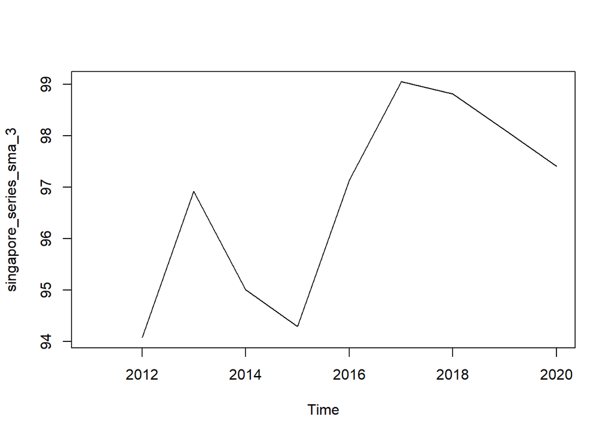

```r
singapore_series_sma_3=SMA(singapore_time_series,n = 2)
plot.ts(singapore_series_sma_3)
```

As we already saw in the data without smooting that there is an upward trend of this variable as it pick in 2013, then goes a bit down in the 2014-15 to pick again in the following years